# Analiza wykresów w mediach

Katarzyna Rogalska

2023-11-03

Cel projektu: Znaleźć wykres opublikowany w ostatnim czasie w mediach oraz zastanowić się jak można go poprawić.

Wykres, który chciałabym ulepszyć został opublikowany 15 października 2023 na stronie:

https://www.moja-gazeta.com.pl/wloszczowa-glosuje-duzo-ludzi-na-wyborach-do-poludnia-frekwencja-wyniosla-ponad-16-procent-i-byla-nizsza-od-wojewodzkiej?fbclid=IwAR13lnt28aKTMkBAYeofLDOJYY1knXWi7ga7KwRtZ5u9FoclTc0WNIKIcTw

Poniżej znajduje się wspomniany wykres:

[figure not shown]

Problemy jakie dostrzegam na tym wykresie to:

- Forma Pie Chart, gdyż ludzkie oko nie umie dokładnie odróżnić bliskich sobie kątów
- Dodatkowo wymiar 3D, który jeszcze bardziej zaburza odbiór. Wartości 15% oraz 11% wcale drastycznie się nie różnią, a na wykresie zielony fragment wydaje się być dużo większy, ponieważ jest “bliżej”
- Niewidoczny wynik procentowy dla komitetu Bezpartyjnych Samorządowców przez źle dobrane kolory
- Podwójne rozróżnienie tej samej kategorii. Komitety wyborcze są rozróżniane zarówno kolorami, jak i poprzez umieszczenie ich logo na wykresie
- Mylący tytuł wykresu. Z artykułu dowiadujemy się, że są to wyniki tylko dla powiatu włoszczowskiego, tytuł może jednak sugerować, że dane dotyczą ostatecznych wyników wyborów.

Tworzę ramkę danych z danymi przepisanymi z wykresu:

```r
komitety<- c("Prawo i Sprawiedliwość","Trzecia droga","Koalicja Obywatelska","Konfederacja","Nowa Lewica","Bezpartyjni Samorządowcy")
wyniki<- c(57.04, 15.48, 11.89, 6.51, 5.47, (100-57.04-15.48-11.89-6.51-5.47))
df<- data.frame(komitety,wyniki)
df
```

```
##                   komitety wyniki
## 1   Prawo i Sprawiedliwość  57.04
## 2            Trzecia droga  15.48
## 3     Koalicja Obywatelska  11.89
## 4             Konfederacja   6.51
## 5              Nowa Lewica   5.47
## 6 Bezpartyjni Samorządowcy   3.61
```

Tworzę nowy wykres w oparciu o te dane:

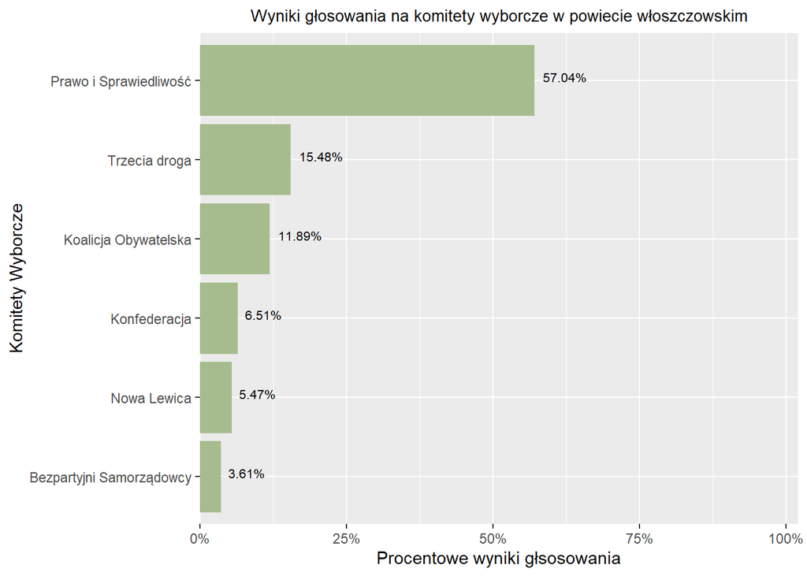

```r
library(ggplot2)
library(scales)
library(forcats)
library(dplyr)
df %>%
  mutate(komitety =fct_reorder(komitety,wyniki)) %>%
  ggplot(aes(x=komitety, y= wyniki, fill ='#A6BC8E'))+
  scale_fill_identity()+
  geom_col()+
  scale_y_continuous(labels=scales::percent_format(scale=1), limits = c(0,100), expand = c(0, 0, 0,2))+
  coord_flip()+
  geom_text(aes(label=paste0(wyniki,"%")), vjust=0.1, hjust=-0.2, size=2.8)+
  labs(title ="Wyniki głosowania na komitety wyborcze w powiecie włoszczowskim",
       y="Procentowe wyniki głsosowania",
       x="Komitety Wyborcze")+
  theme(plot.title= element_text(size=10, hjust=0.5, family='bold'))->plot1
plot1
```

W moim wykresie dokonałam następujących zmian:

- Wybrałam formę wykresu kolumnowego, z której można odczytać dane bez zaburzonej skali wielkości
- Oprócz wartości procentowych na osi X dodałam też dokładne wartości przy kolumnie każdego komitetu, aby wykres nie stracił na dokładności
- Zrezygnowałam z podziału na kolory, który może sugerować nieistniejące rozróżnienie danych po jakiejś nieznanej zmiennej
- Zdecydowałam się na wybór wykresu poziomego, aby łatwo można było odczytać nazwy komitetów
- Zadbałam by kolumny pokazane były w porządku malejącym, aby nie stracić na łatwości odczytu danych
- Zmieniłam tytuł wykresu, aby lepiej informował odbiorcę z jakimi danymi ma do czynienia
- Zrezygnowałam z logotypów komitetów, gdyż mamy już ich nazwy na osi y

Podumowując, główną zmianą, którą wprowadziłam jest zrezygnowanie z formy wykresu kołowego 3D, która znacznie zaburza odbiór danych oraz wygenerowanie zamiast tego wykresu kolumnowego o jednym kolorze z zaznaczonymi dokładnymi wynikami procentowymi.